# Preliminary Analysis

## __________PREPARATION__________

### Data subsetting and cleaning

```r
dataov = dataov %>%
  rename(Suicide = `Suicide Rate`, Unemployment = `Unemployment Rate`,
         RespDeath = `Chronic Lower Resp. Disesases (Deaths)`,
         HeartDeath = `Heart Diseases (Deaths)`,
         LiverDeath = `Chronic liver disease and cirrhosis (Deaths)`,
         CerebroDeath = `Cerebrovascular diseases (Deaths)`)
```

```r
data = na.omit(data)
```

```r
#Converting data units
data$Salary = as.numeric(data$Salary/1000)
data$Bankruptcy = as.numeric(data$Bankruptcy/1000)
```

### Explanation of variables

_____data_____

- 1. Suicide: suicide counts per 100,000 resident population (1950, 1960, 1970, 1980-2017, age-adjusted/crude) [age group, gender X age group, gender X race X age group]
- 2. Unemployment: unemployment rate > age 16 (1995-1999, 2001-2019, thousands/rate) [age group x gender x race]
- 3. Salary: median annual earnings of full-time workers > age 15 (1960-2017) [gender, gender X race]
- 4. DrugDeath: drug-induced deaths per 100,000 resident population (1999-2017, age-adjusted/crude, drug type) [age group, gender X age group, gender X race]d
- 5. AlcoholDeath: alcohol-induced deaths per 100,000 resident population (1999-2017, age-adjusted) [gender X race]
- 6. RespDeath, HeartDeath, LiverDeath, CerebroDeath: rate of disease deaths per 100,000 resident population (1950, 1960, 1970, 1980-2017, disease type) [gender, race]
- 7. Poverty: percentage of age group below poverty (various periods) [age group x race]
- 8. Bankrupt: annual counts of business and non‐business filings by year (1980‐2019)
- 9. Firearms: counts of firearms background checks initiated through the NICS (Monthly, November 1998 to May 31, 2020)
- Mortality data is used to proxy the severeness of that condition in the country
- With the gender and race dimension, available data decreases from dataov.

_____dataov_____ * a) Unemployment Rate: annual (aggregate) 1980-2017 * b) Suicide Rate: annual (aggregate) 1980-2017

### Sources

- (1,4, b) Retrieved: https://www.cdc.gov/nchs/hus/contents2018.htm (tables 009, 008, 009)
- 2. Retrieved: https://www.bls.gov/cps/cps_aa2003.htm (2003-2017) “24-Unemployed persons by marital status, race, Hispanic or Latino ethnicity, age, and sex”
- 3. Retrieved: https://www.dol.gov/agencies/wb/data/earnings#COLLAPSE-earnings-by-sex-race-hispanic-ethnicity
- 5. Retrieved: https://www.cdc.gov/nchs/data/nvsr/nvsr68/nvsr68_09_tables-508.pdf (table I-2 (3))
- 6. Retrieved: https://www.cdc.gov/nchs/hus/contents2018.htm#Table_005
- 7. Retrieved https://www.census.gov/data/tables/time-series/demo/income-poverty/historical-poverty-people.html (table 3)
- 8. Retrieved https://www.abi.org/newsroom/bankruptcy-statistics?page=28 (Annual Business and Non‐business Filings by Year (1980‐2019)
- 1. Retrieved: https://data.bls.gov/timeseries/LNU04000000?periods=Annual+Data&periods_option=specific_periods&years_option=all_years

## __________DESCRIPTIVE STATISTICS__________

### Pair-wise correlation plots: DATAOV

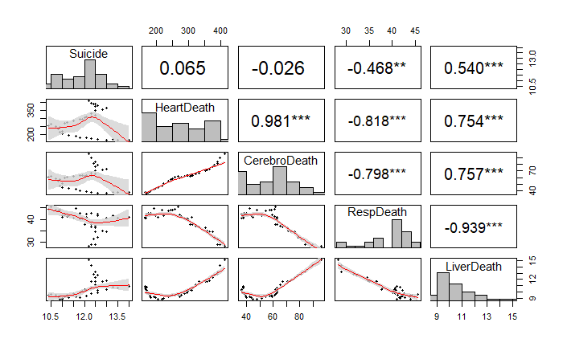

```r
pairs.panels(dataov[,c("Suicide", "HeartDeath", "CerebroDeath", "RespDeath", "LiverDeath")],
             method = "pearson", density = FALSE, ellipses = FALSE, scale = FALSE,
             rug = FALSE, ci = TRUE, stars = TRUE, hist.col = "GREY", digits = 3, cex = 0.85)
```

### Pair-wise correlation plots: DATA

```r
corplotdata = data
#[data$Gender == "Female" & data$Race == "White",]
```

png(“GLMM - Correlation Plot 1.png”, units=“in”, width=7, height=5, res=1080) dev.off()

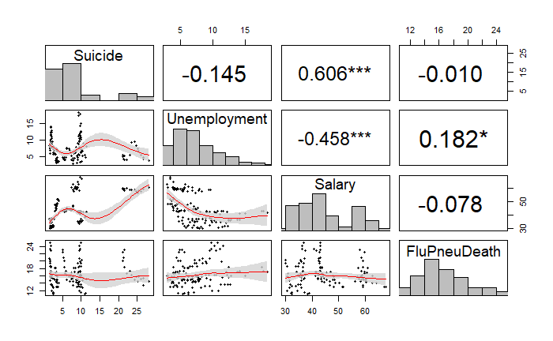

```r
pairs.panels(corplotdata[,c("Suicide", "Unemployment", "Salary", "FluPneuDeath")],
             method = "pearson", density = FALSE, ellipses = FALSE, scale = FALSE,
             rug = FALSE, ci = TRUE, stars = TRUE, hist.col = "GREY", digits = 3, cex = 0.85)
```

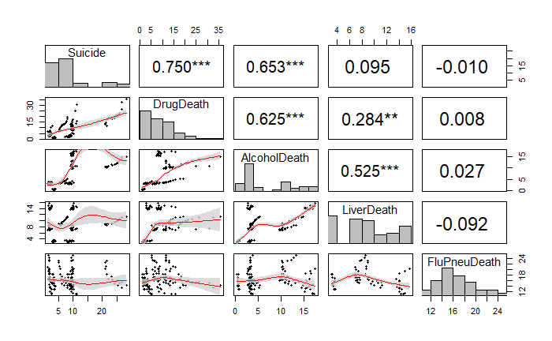

```r
pairs.panels(corplotdata[,c("Suicide", "DrugDeath", "AlcoholDeath", "LiverDeath",
                            "FluPneuDeath")],
             method = "pearson", density = FALSE, ellipses = FALSE, scale = FALSE,
             rug = FALSE, ci = TRUE, stars = TRUE, hist.col = "GREY", digits = 3, cex = 0.85)
```

### Time series plots

png(“OV - Suicide and Unemployment.png”, units=“in”, width=7, height=5, res=1080) dev.off()

```r
plot(x = dataov$Year, y = dataov$Suicide,
     type = "l", col = "DARKRED", axes = FALSE, ylim = c(4,16),
     main = "Suicide and Unemployment",
     xlab = "Year", ylab = "", lwd =2)
lines(x = dataov$Year, y = dataov$Unemployment,
      type = "l", col = "DARKBLUE", lwd = 2)
```

```r
axis(side = 1, at = 1980:2017, las = 1, cex = 0.5)
axis(side = 2, at = 4:16, las = 2)
```

```r
mtext("Unemployment Rate (%)", side = 2, line = 2.5, col = "DARKBLUE")
axis(side = 4, at = 4:16, las = 2)
```

```r
mtext("Suicide Counts per 100k Population", side = 4, line = -1, col = "DARKRED")

abline(h = 4:16, v = 1980:2017, col = "GREY", lty = "dotted")
```

```r
legend(x = 1980, y = 16, legend = c("Suicide Counts per 100k", "Unemployment Rate"),
       col = c("RED", "BLACK"), lty = 1, lwd = 2, cex = 0.7, bg = "LIGHTGREY")

year1 = 2001; rate1 = dataov$Suicide[dataov$Year == year1]
segments(x0 = year1, y0 = 0, x1 = year1, y1 = rate1, lty = 2)
```

```r
legend(x = year1, y = rate1-1.5, legend = "Dotcom Bubble", cex = 0.6)

year2 = 2008; rate2 = dataov$Suicide[dataov$Year == year2]
segments(x0 = year2, y0 = 0, x1 = year2, y1 = rate2, lty = 2)
```

```r
legend(x = year2, y = rate2-0.5, legend = "2008 Crisis", cex = 0.6)

year3 = 1989; rate3 = dataov$Suicide[dataov$Year == year3]
segments(x0 = year3, y0 = 0, x1 = year3, y1 = rate3, lty = 2)
```

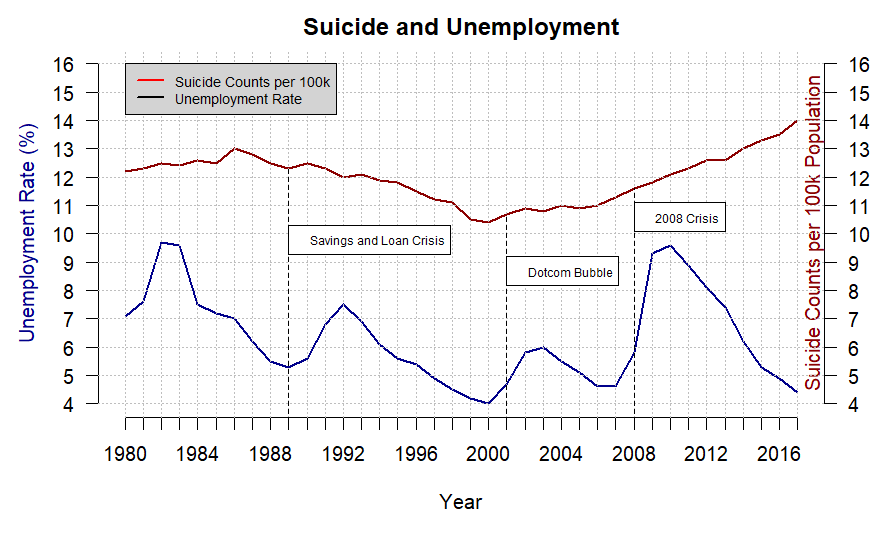

```r
legend(x = year3, y = rate3-2, legend = "Savings and Loan Crisis", cex = 0.6)
```

```r
plot(x = dataov$Year, y = dataov$Suicide,
     type = "l", col = "RED", axes = FALSE, ylim = c(8,16),
     main = "Suicide and Chronic Liver Diseases Deaths",
     xlab = "Year", ylab = "", lwd =2)
lines(x = dataov$Year, y = dataov$LiverDeath,
      type = "l", col = "BLUE", lwd = 2)
```

```r
axis(side = 1, at = 1980:2017, las = 2)
axis(side = 2, at = 8:16, las = 2)
```

```r
mtext("Deaths from Chronic Liver Diseases per 100k", side = 2, line = 2.5, col = "BLUE")
axis(side = 4, at = 8:16, las = 2)
```

```r
mtext("Suicide Counts per 100k Population", side = 4, line = -1, col = "RED")

abline(h = 4:16, v = 1980:2017, col = "GREY", lty = "dotted")
```

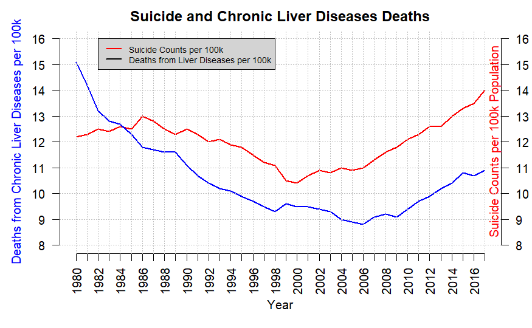

```r
legend(x = 1982, y = 16, legend = c("Suicide Counts per 100k", "Deaths from Liver Diseases per 100k"),
       col = c("RED", "BLACK"), lty = 1, lwd = 2, cex = 0.7, bg = "LIGHTGREY")
```

- Clear rise in unemployment rate after 2008. However, such spikes are not observed in suicide trends, indicating unemployment rate does not explain suicide rates well.